# Week 11 - In-Class Exercise

STA 235H - Fall 2023

# Setup

In this exercise, we will be working with the same data as before!

You work at a marketing firm, and are trying to predict characteristics for different segments of your audience (customers from a car insurance company). You have the following dataset that will help you build your model:

```r
library(tidyverse)
library(caret)
library(modelr)

marketing = read.csv("https://raw.githubusercontent.com/maibennett/sta235/main/exampleSite/content/Classes/Week10/1_ModelSelection/data/marketing.csv")

# For simplicity, we will drop some variables, but you can use them all afterward if you want!
marketing = marketing %>% select(Customer, Customer.Lifetime.Value, Response, Coverage, Education, EmploymentStatus,
                                  Gender, Income, Location.Code, Marital.Status, Monthly.Premium.Auto,
                                  Months.Since.Last.Claim, Number.of.Policies,
                                  Policy.Type, Sales.Channel, Total.Claim.Amount, Renew.Offer.Type)
```

Here’s the list of some variables in your dataset:

- `Customer`: Customer ID (*Note: ID variables are usually not predictors!*)
- `Customer.Lifetime.Value`: Estimate of the value of a customer (*In this example, this is what we will predict*)
- `Response`: Whether the client took the offer or not
- `Coverage`: Type of insurance coverage
- `Education`, `Gender`, `Income`, `Location.Code`, `Marital.Status`: Client’s characteristics.
- `Renew.Offer.Type`: Offer made to the client (out of four different options)
- `Response`: Whether a customer responds to an offer or not.

Continuing with the task we were doing last week, run the following code and start from there:

```r
marketing = marketing %>% select(-Customer) %>% mutate(Response = ifelse(Response=="No", 0, 1))

marketing = marketing %>% mutate_if(is.character, as.factor)

set.seed(100) #Remember always to set seed before something random (in this case, sample())

n = nrow(marketing) #Number of obs in our marketing dataset

train = sample(1:n, nrow(marketing)*0.75) #Row numbers for 75% of our data (randomly selected)

train.data = marketing %>% slice(train)
test.data = marketing %>% slice(-train)
```

## Tasks

**Q2: What is your optimal lambda in this case?** **Q3: What is your percentage of accuracy?**

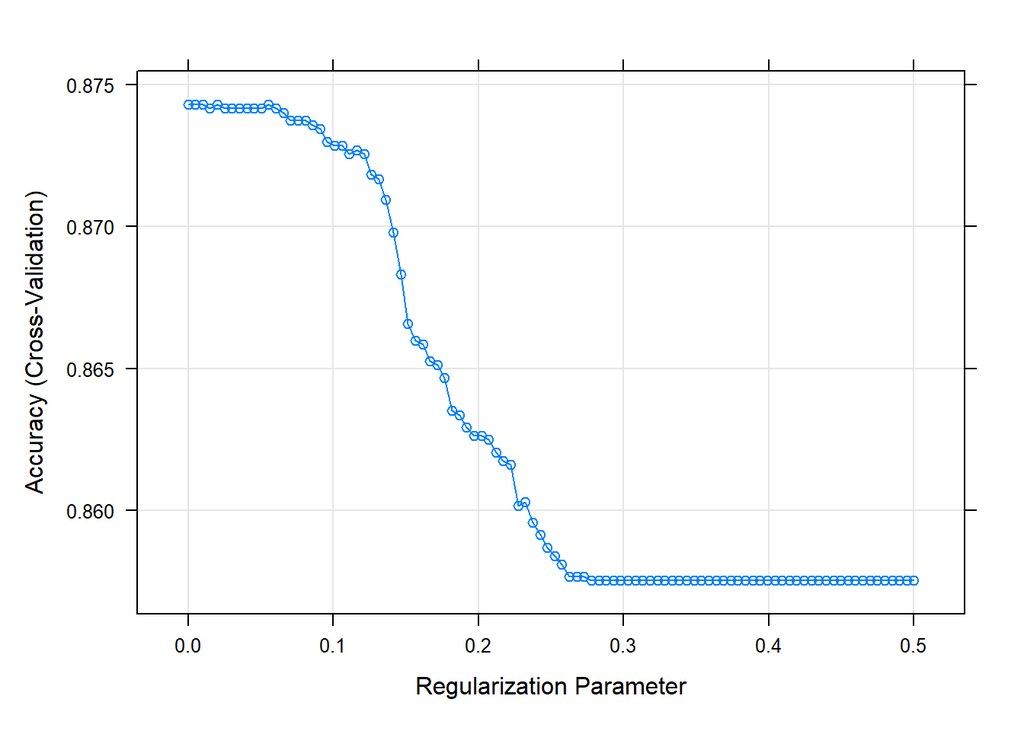

```r
lambda_seq = seq(0,0.5,length = 100)

set.seed(100)

train.control = trainControl(method = "cv", number = 10)

ridge = train(factor(Response) ~ . , data = train.data,
               method = "glmnet",
               preProcess = "scale",
               trControl = trainControl("cv", number = 10),
               tuneGrid = expand.grid(alpha = 0,
                                      lambda = lambda_seq)
)

plot(ridge)
```

```r
ridge$bestTune
```

|  | alpha | lambda |
| --- | --- | --- |
| 3 | 0 | 0.010101 |

```r
# Predict response:
pred.values = ridge %>% predict(test.data)

# How many do we get right? (on average)
mean(pred.values == test.data$Response)
```

```
## [1] 0.8704028
```

3. Do the same exercise as 2) but now with lasso instead of ridge:

**Q4: What is your percentage of accuracy?** **Q5: How many variables does your model have?**

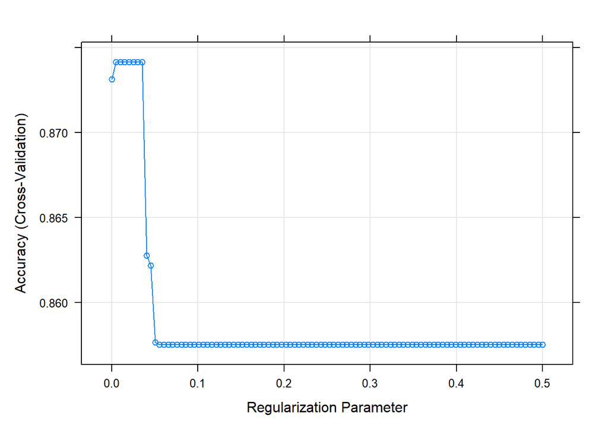

```r
lambda_seq = seq(0,0.5,length = 100)

set.seed(100)

train.control = trainControl(method = "cv", number = 10)

lasso = train(factor(Response) ~ . , data = train.data,
               method = "glmnet",
               preProcess = "scale",
               trControl = trainControl("cv", number = 10),
               tuneGrid = expand.grid(alpha = 1,
                                      lambda = lambda_seq)
)

plot(lasso)
```

```r
# Predict response:
pred.values = lasso %>% predict(test.data)

# How many do we get right? (on average)
mean(pred.values == test.data$Response)
```

```
## [1] 0.869965
```

```r
# Let's see the coefficients in the model:
coef(lasso$finalModel, lasso$bestTune$lambda)
```

```
## 30 x 1 sparse Matrix of class "dgCMatrix"
##                                        s1
## (Intercept)                   -1.97448116
## Customer.Lifetime.Value        .
## CoverageExtended               .
## CoveragePremium                .
## EducationCollege               .
## EducationDoctor                .
## EducationHigh School or Below  .
## EducationMaster                .
## EmploymentStatusEmployed       .
## EmploymentStatusMedical Leave  .
## EmploymentStatusRetired        0.35972690
## EmploymentStatusUnemployed     .
## GenderM                        .
## Income                         .
## Location.CodeSuburban          .
## Location.CodeUrban             .
## Marital.StatusMarried          .
## Marital.StatusSingle           .
## Monthly.Premium.Auto           .
## Months.Since.Last.Claim        .
## Number.of.Policies             .
## Policy.TypePersonal Auto       .
## Policy.TypeSpecial Auto        .
## Sales.ChannelBranch            .
## Sales.ChannelCall Center       .
## Sales.ChannelWeb               .
## Total.Claim.Amount             .
## Renew.Offer.TypeOffer2         0.16742627
## Renew.Offer.TypeOffer3        -0.07443690
## Renew.Offer.TypeOffer4        -0.08788983
```

```r
# You can also store them in an object, and then look at p!
# This is the number of coefficients (variables + intercept)
coefs = coef(lasso$finalModel, lasso$bestTune$lambda)

coefs@p[2] - 1
```

```
## [1] 4
```